# Crowding in Grampian

### Background

Scotland is divided into 7000 Data Zones of about 500-1000 people each.  
This is a short report about which zones in Grampian have:  
1) many people living in crowded homes, or  
2) many people living in a crowded neighbourhood,  
or both.

### Finding neighbourhoods with dense populations and crowded homes

The two figures below show all the Data Zones for Aberdeen City mapped for their percent of people living in overcrowded homes versus the datazone’s total density (population/km2).

Datazones are red if they are in the 95th percentile or above on either measure. The second figure is the same as the first but with the red points labeled.

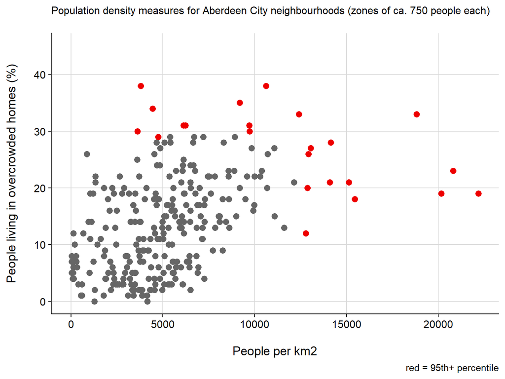

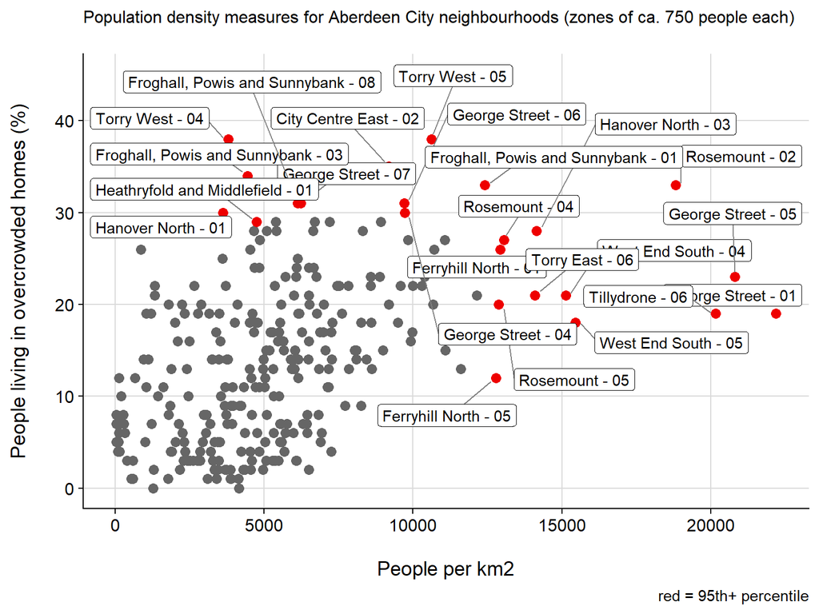

### Mapping the most crowded

This map shows data zones where either the overcrowding rate, the population per km2, or both is 95th percentile or above.  
These areas are the same as those in red the the figures above.  
Zoom/click for more information on each zone.

[interactive chart not shown]

### Ranking the most crowded

Data Zones with most people living in overcrowded homes or most people per km2 (95th+ percentile)

Top 5% of Data Zones with people living in overcrowded homes or most people per km2

| Data Zone | Population | People living overcrowded (%) | Population/km2 | Overcrowded percentile | Pop/km2 percentile |
| --- | --- | --- | --- | --- | --- |
| Rosemount - 02 | 1000 | 33 | 18,825 | 98 | 99 |
| Froghall, Powis and Sunnybank - 01 | 1204 | 33 | 12,414 | 98 | 94 |
| Torry West - 05 | 1055 | 38 | 10,618 | 100 | 91 |
| Hanover North - 03 | 698 | 28 | 14,150 | 90 | 97 |
| Rosemount - 04 | 744 | 27 | 13,060 | 88 | 96 |
| City Centre East - 02 | 626 | 35 | 9,190 | 99 | 85 |
| George Street - 04 | 1751 | 30 | 9,728 | 96 | 87 |
| George Street - 06 | 801 | 31 | 9,706 | 96 | 87 |
| Ferryhill North - 01 | 744 | 26 | 12,932 | 86 | 96 |
| George Street - 05 | 954 | 23 | 20,807 | 81 | 100 |
| West End South - 04 | 1105 | 21 | 15,131 | 75 | 98 |
| Torry East - 06 | 798 | 21 | 14,097 | 75 | 97 |
| Tillydrone - 06 | 891 | 19 | 20,165 | 70 | 99 |
| George Street - 01 | 688 | 19 | 22,189 | 68 | 100 |
| Rosemount - 05 | 921 | 20 | 12,885 | 72 | 95 |
| George Street - 07 | 677 | 31 | 6,228 | 97 | 66 |
| West End South - 05 | 1048 | 18 | 15,458 | 64 | 98 |
| Froghall, Powis and Sunnybank - 08 | 773 | 31 | 6,133 | 97 | 65 |
| Heathryfold and Middlefield - 01 | 877 | 29 | 4,758 | 95 | 45 |
| Froghall, Powis and Sunnybank - 03 | 505 | 34 | 4,443 | 99 | 40 |
| Ferryhill North - 05 | 956 | 12 | 12,782 | 43 | 95 |
| Torry West - 04 | 818 | 38 | 3,800 | 100 | 34 |
| Hanover North - 01 | 1044 | 30 | 3,624 | 95 | 30 |

### Characteristics of the most crowded

Data Zones with most people living in overcrowded homes or most people per km2 (95th+ percentile)

Top 5% of Data Zones with people living in overcrowded homes or most people per km2

| Data Zone | Population | % Not born UK/ROI | % BAME | % Polish | % Not working age |
| --- | --- | --- | --- | --- | --- |
| Rosemount - 02 | 1000 | 27 | 14 | 5 | 11 |
| Froghall, Powis and Sunnybank - 01 | 1204 | 33 | 19 | 10 | 16 |
| Torry West - 05 | 1055 | 40 | 12 | 22 | 18 |
| Hanover North - 03 | 698 | 21 | 14 | 3 | 9 |
| Rosemount - 04 | 744 | 20 | 11 | 4 | 18 |
| City Centre East - 02 | 626 | 36 | 27 | 5 | 9 |
| George Street - 04 | 1751 | 29 | 15 | 4 | 8 |
| George Street - 06 | 801 | 31 | 18 | 5 | 15 |
| Ferryhill North - 01 | 744 | 24 | 15 | 4 | 16 |
| George Street - 05 | 954 | 23 | 16 | 4 | 13 |
| West End South - 04 | 1105 | 23 | 10 | 5 | 14 |
| Torry East - 06 | 798 | 17 | 4 | 10 | 37 |
| Tillydrone - 06 | 891 | 37 | 7 | 28 | 33 |
| George Street - 01 | 688 | 20 | 11 | 9 | 26 |
| Rosemount - 05 | 921 | 27 | 13 | 3 | 11 |
| George Street - 07 | 677 | 29 | 18 | 3 | 21 |
| West End South - 05 | 1048 | 29 | 19 | 4 | 12 |
| Froghall, Powis and Sunnybank - 08 | 773 | 28 | 14 | 4 | 13 |
| Heathryfold and Middlefield - 01 | 877 | 27 | 4 | 17 | 30 |
| Froghall, Powis and Sunnybank - 03 | 505 | 39 | 22 | 11 | 27 |
| Ferryhill North - 05 | 956 | 21 | 13 | 1 | 15 |
| Torry West - 04 | 818 | 31 | 7 | 14 | 17 |
| Hanover North - 01 | 1044 | 24 | 16 | 3 | 15 |

### Sources

Data Zone area (km2) and location and were taken from here: https://data.gov.uk/dataset/ab9f1f20-3b7f-4efa-9bd2-239acf63b540/data-zone-boundaries-2011

Total population, working age population, overcrowded rate and postcode mapping were taken from the Scottish Index of Multiple Deprivation 2020 version 2 https://www.gov.scot/collections/scottish-index-of-multiple-deprivation-2020/

Country of birth and ethnicity were taken from the 2011 Census https://www.scotlandscensus.gov.uk/ods-web/data-warehouse.html

Code and data at https://github.com/JessButler/crowding

Contact jessicabutler@abdn.ac.uk